# Kaggle competition “Titanic: Machine Learning from Disaster”

Konstantin Greger

Thursday, May 21, 2015

## Loading the data

I followed [Curt’s](https://github.com/wehrley/wehrley.github.io/blob/master/SOUPTONUTS.md) approach of loading the CSV files from my GitHub repo, but instead of his self-developed function based on `read.csv` I decided to use Hadley Wickham’s [`readr`package](https://github.com/hadley/readr).

```r
suppressMessages(library(caret))
suppressMessages(library(e1071))
suppressMessages(library(Hmisc))
suppressMessages(library(plyr))
suppressMessages(library(dplyr))
suppressMessages(library(pROC))
suppressMessages(library(readr))
suppressMessages(library(reshape2))
suppressMessages(library(stringr))
suppressMessages(library(vcd))

path <- "https://raw.github.com/kogreger/kaggle_titanic/master/"
trainFile <- "train.csv"
testFile <- "test.csv"

train <- read_csv(paste0(path, trainFile), col_types = list(
    PassengerId = col_integer(),
    Survived = col_factor(c("0", "1")),
    Pclass = col_factor(c("1", "2", "3")),
    Name = col_character(),
    Sex = col_factor(c("male", "female")),
    Age = col_double(),
    SibSp = col_integer(),
    Parch = col_integer(),
    Ticket = col_character(),
    Fare = col_numeric(),
    Cabin = col_character(),
    Embarked = col_factor(c("C", "Q", "S")))) %>%
    tbl_df()
test <- read_csv(paste0(path, testFile), col_types = list(
    PassengerId = col_integer(),
    Pclass = col_factor(c("1", "2", "3")),
    Name = col_character(),
    Sex = col_factor(c("male", "female")),
    Age = col_double(),
    SibSp = col_integer(),
    Parch = col_integer(),
    Ticket = col_character(),
    Fare = col_numeric(),
    Cabin = col_character(),
    Embarked = col_factor(c("C", "Q", "S")))) %>%
    tbl_df()

train
```

```
## Source: local data frame [891 x 12]
##
##    PassengerId Survived Pclass
## 1            1        0      3
## 2            2        1      1
## 3            3        1      3
## 4            4        1      1
## 5            5        0      3
## 6            6        0      3
## 7            7        0      1
## 8            8        0      3
## 9            9        1      3
## 10          10        1      2
## ..         ...      ...    ...
## Variables not shown: Name (chr), Sex (fctr), Age (dbl), SibSp (int), Parch
##   (int), Ticket (chr), Fare (dbl), Cabin (chr), Embarked (fctr)
```

```r
test
```

```
## Source: local data frame [418 x 11]
##
##    PassengerId Pclass                                         Name    Sex
## 1          892      3                             Kelly, Mr. James   male
## 2          893      3             Wilkes, Mrs. James (Ellen Needs) female
## 3          894      2                    Myles, Mr. Thomas Francis   male
## 4          895      3                             Wirz, Mr. Albert   male
## 5          896      3 Hirvonen, Mrs. Alexander (Helga E Lindqvist) female
## 6          897      3                   Svensson, Mr. Johan Cervin   male
## 7          898      3                         Connolly, Miss. Kate female
## 8          899      2                 Caldwell, Mr. Albert Francis   male
## 9          900      3    Abrahim, Mrs. Joseph (Sophie Halaut Easu) female
## 10         901      3                      Davies, Mr. John Samuel   male
## ..         ...    ...                                          ...    ...
## Variables not shown: Age (dbl), SibSp (int), Parch (int), Ticket (chr),
##   Fare (dbl), Cabin (chr), Embarked (fctr)
```

## Processing the data (a.k.a. “data munging”)

I like the idea of visualizing the missing values to get an idea of the situation, but again I used a different method to do so, using `image`:

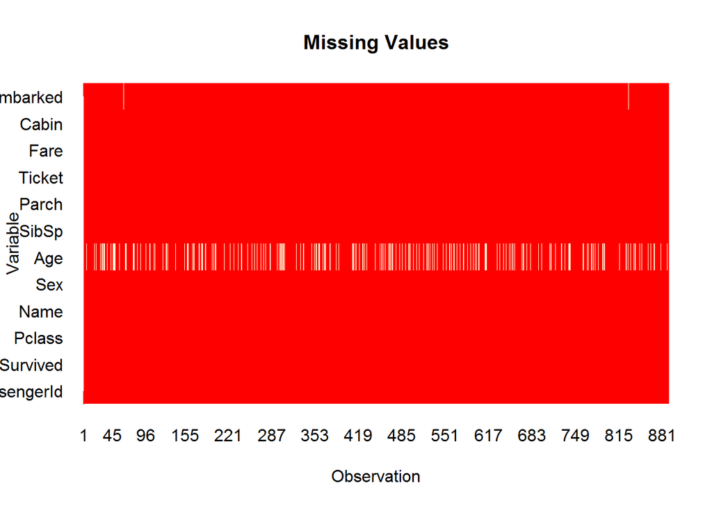

```r
image(is.na(train),
      main = "Missing Values",
      xlab = "Observation",
      ylab = "Variable",
      xaxt = "n",
      yaxt = "n",
      bty = "n")
axis(1, seq(0, 1, length.out = nrow(train)), 1:nrow(train), col = "white")
axis(2, seq(0, 1, length.out = length(train)), names(train), col = "white", las = 2)
```

This is a picture dramatically different from the situation that Curt encountered with his data loading scheme. Since I don’t care about the cabin numbers for now I don’t regard empty fields here as missing data.

Next was some general descriptive statistics on the various attributes of the data:

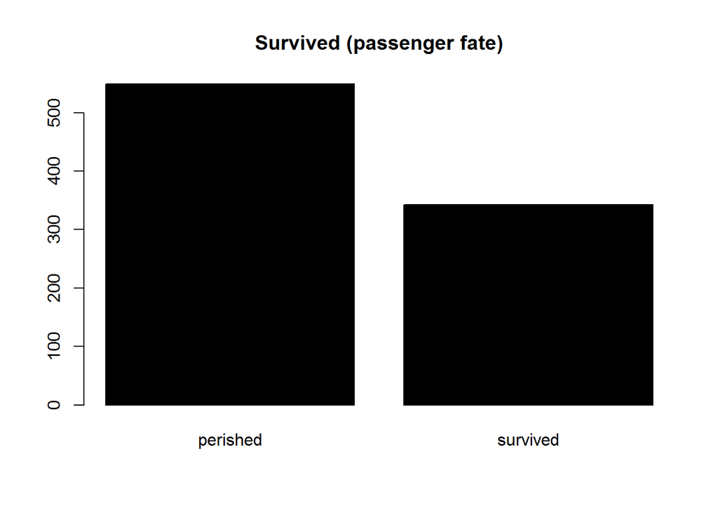

```r
barplot(table(train$Survived),
        names.arg = c("perished", "survived"),
        main = "Survived (passenger fate)",
        col = "black")
```

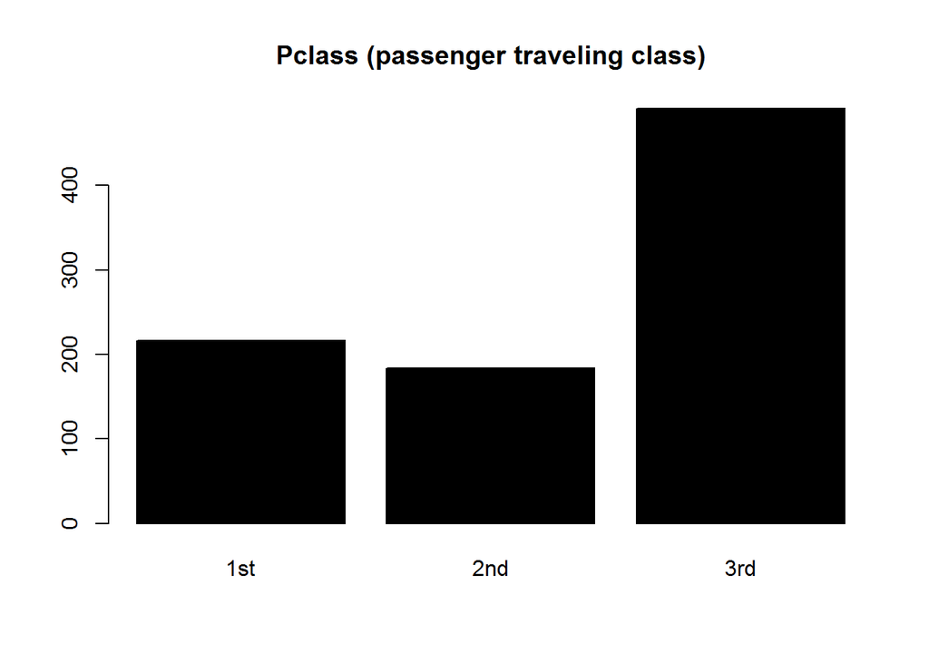

```r
barplot(table(train$Pclass),
        names.arg = c("1st", "2nd", "3rd"),
        main = "Pclass (passenger traveling class)",
        col = "black")
```

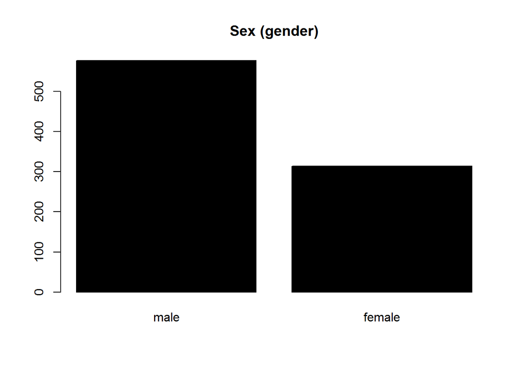

```r
barplot(table(train$Sex),
        main = "Sex (gender)",
        col = "black")
```

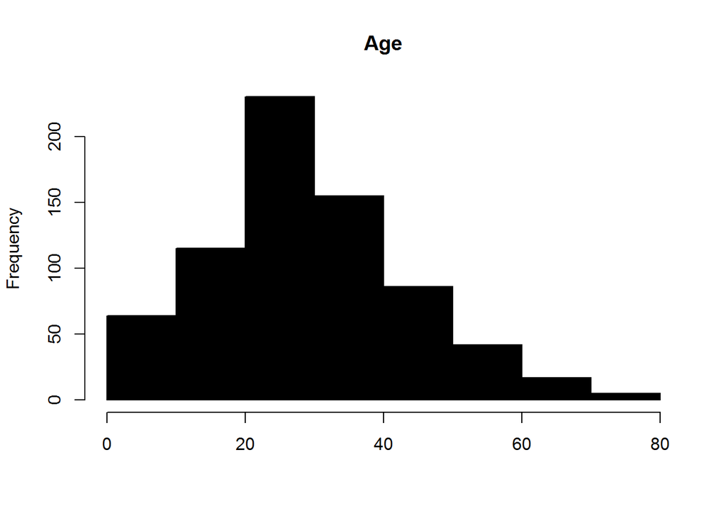

```r
hist(train$Age,
     main = "Age",
     xlab = NULL,
     col = "black")
```

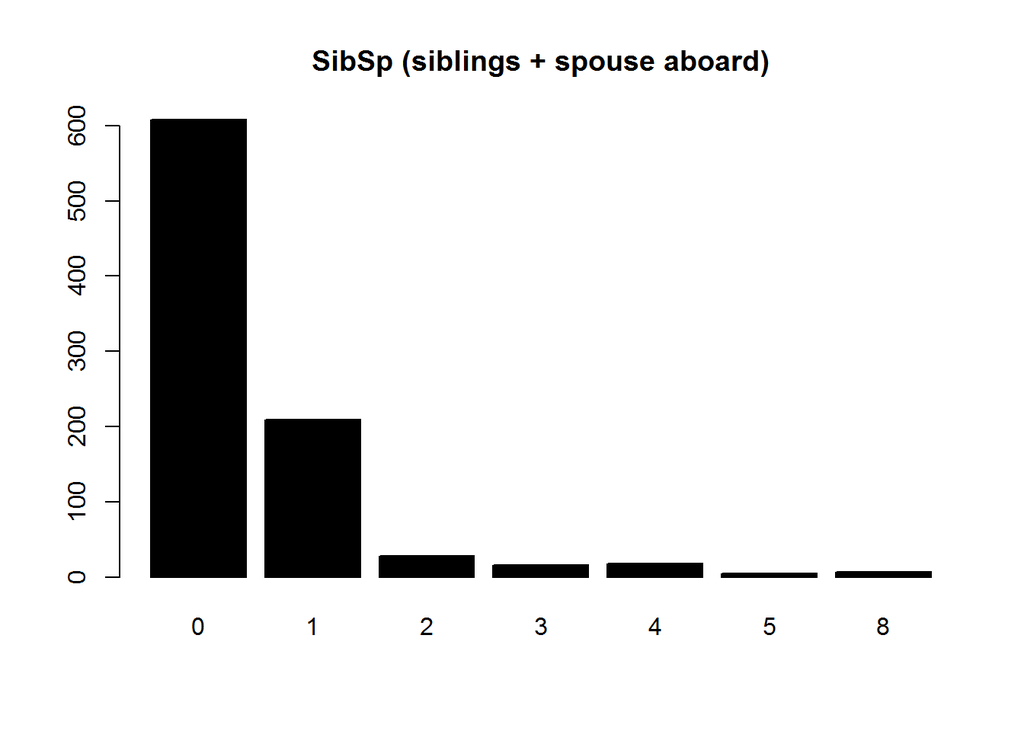

```r
barplot(table(train$SibSp),
        main = "SibSp (siblings + spouse aboard)",
        col = "black")
```

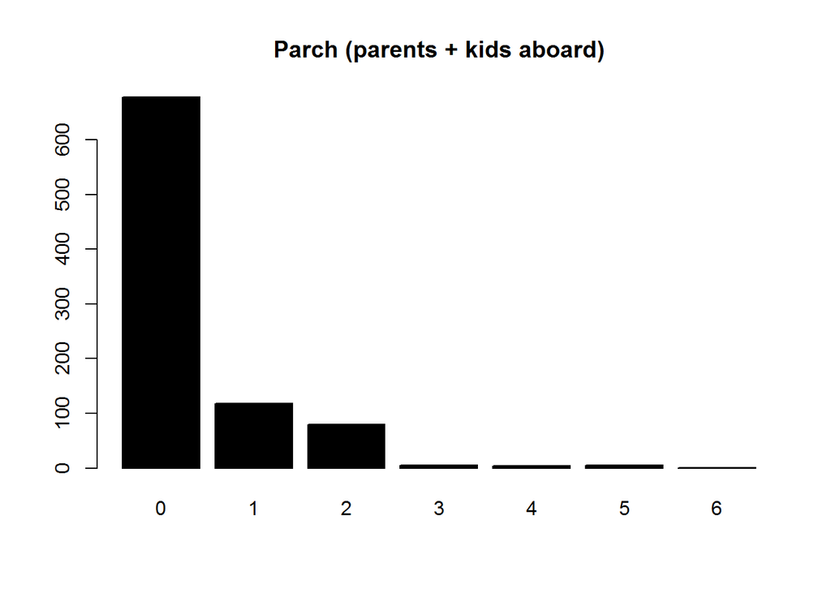

```r
barplot(table(train$Parch),
        main = "Parch (parents + kids aboard)",
        col = "black")
```

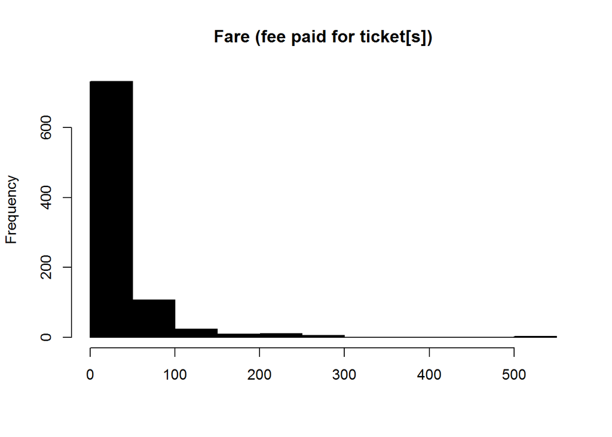

```r
hist(train$Fare,
     main = "Fare (fee paid for ticket[s])",
     xlab = NULL,
     col = "black")
```

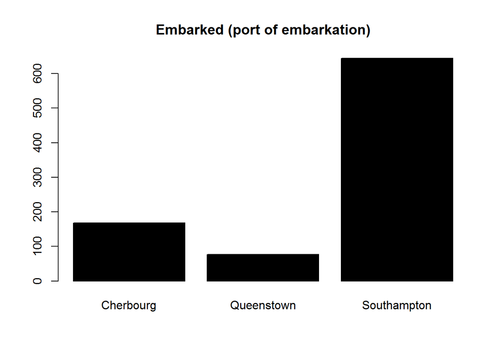

```r
barplot(table(train$Embarked),
        names.arg = c("Cherbourg", "Queenstown", "Southampton"),
        main = "Embarked (port of embarkation)",
        col = "black")
```

While some interesting trends are visible (more men than women, more 3rd class passengers than 1st and 2nd class, mostly younger people, almost everybody embarked in Southampton, …) it only becomes interesting to look at the data from a multivariate perspective. Just like Curt I escpecially like mosaic plots for this purpose:

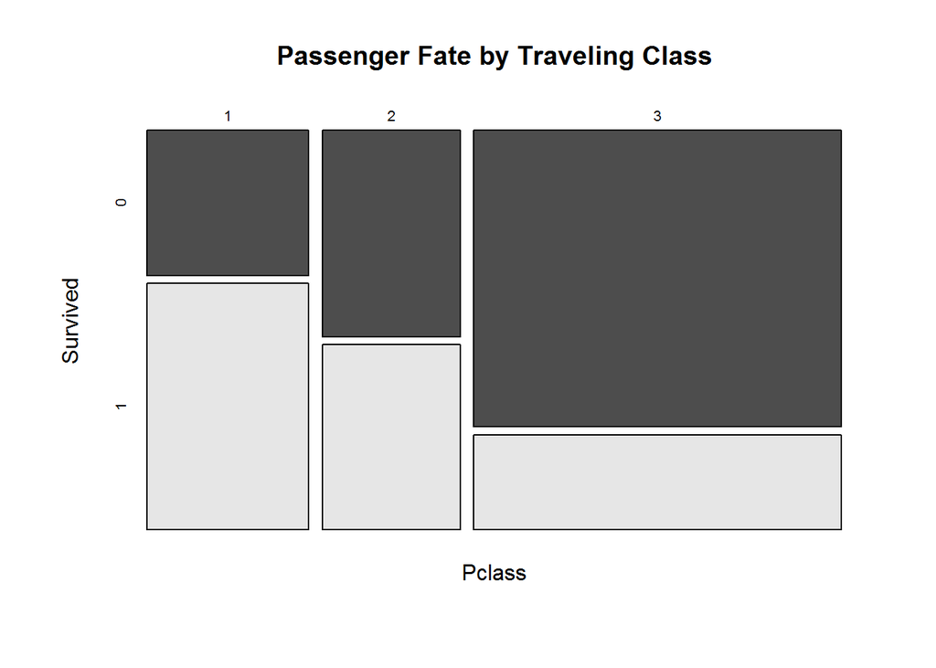

```r
mosaicplot(train$Pclass ~ train$Survived,
           main="Passenger Fate by Traveling Class",
           shade = FALSE,
           color = TRUE,
           xlab = "Pclass",
           ylab = "Survived")
```

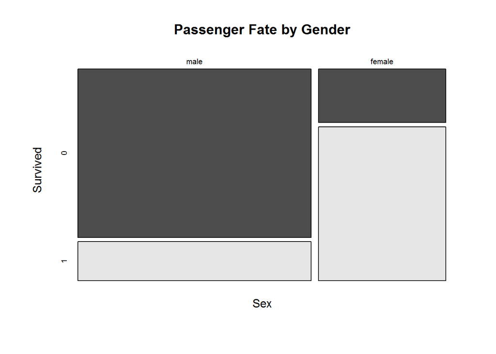

```r
mosaicplot(train$Sex ~ train$Survived,
           main = "Passenger Fate by Gender",
           shade = FALSE,
           color = TRUE,
           xlab = "Sex",
           ylab = "Survived")
```

These two plots are hinting at two of the (probably) most important factors for our model: gender and class. It seems as if especially men and 3rd class passengers had a significantly lower survival rate than their female and/or upper-class counterparts.

Age on the other hand did not seem to be a factor for survival, although more older people seem to have perished:

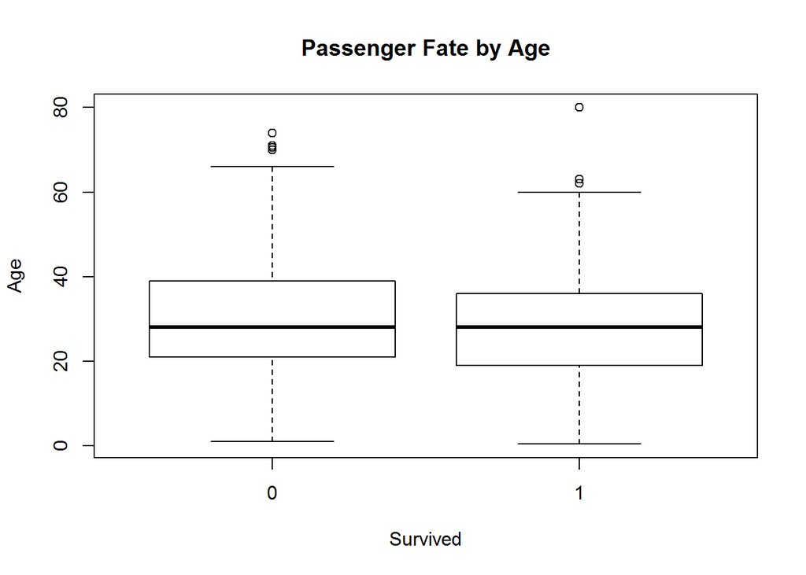

```r
boxplot(train$Age ~ train$Survived,
        main = "Passenger Fate by Age",
        xlab = "Survived",
        ylab = "Age")
```

it is not clear, though, if this was due to the fact that they didnt make it to teh rescue boats in time or were overpowered by younger passengers, or whether it was a conscious choice in order to allow younger people to be rescued.

## Treating missing values

### Age

We have 177 missing values in our age variable. At 891 samples this actually accounts to 19.9% missing. Therefore simple imputation by the mean value (29.7 in this case) will not produce meaningful input data for our model.

#### Attempt 1: Age derived from passenger class

Compared to the age of passengers who perished vs. survived it appears to be a lot more informative to look at the age distributions by class:

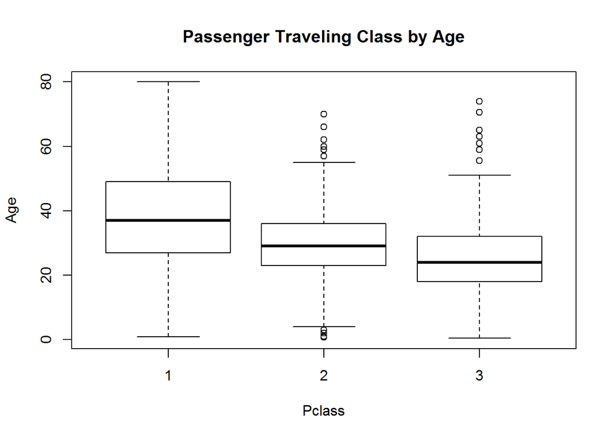

```r
boxplot(train$Age ~ train$Pclass,
        main = "Passenger Traveling Class by Age",
        xlab = "Pclass",
        ylab = "Age")
```

So an average age can be imputed from the traveling class of each passenger as follows:

```r
train <- train %>%
    group_by(Pclass) %>%
    mutate(AgePclass = mean(Age, na.rm = TRUE))

train %>%
    group_by(Pclass) %>%
    summarise(n = n(),
              missing = sum(is.na(Age)),
              mean = mean(Age, na.rm = TRUE),
              median = median(Age, na.rm = TRUE))
```

```
## Source: local data frame [3 x 5]
##
##   Pclass   n missing     mean median
## 1      1 216      30 38.23344     37
## 2      2 184      11 29.87763     29
## 3      3 491     136 25.14062     24
```

#### Attempt 2: Age derived from titles in names

Another attempt suggested by Curt is to make use ot the titles provided for all passengers in their name field. For this purpose he developed a function to extract the title, which I simply reuse here in a single vectorized statement:

```r
# process for extracting honorific (i.e. title) from the Name feature taken
# from https://github.com/wehrley/wehrley.github.io/blob/master/SOUPTONUTS.md
train$Title <- substr(train$Name,
                      regexpr("\\,[A-Z ]{1,20}\\.",
                              train$Name,
                              TRUE) + 2,
                      regexpr("\\,[A-Z ]{1,20}\\.",
                              train$Name,
                              TRUE) +
                          attr(regexpr("\\,[A-Z ]{1,20}\\.",
                                       train$Name,
                                       TRUE),
                               "match.length") - 2)
train <- train %>%
    group_by(Title) %>%
    mutate(AgeTitle = mean(Age, na.rm = TRUE))

train %>%
    group_by(Title) %>%
    summarise(n = n(),
              missing = sum(is.na(Age)),
              mean = mean(Age, na.rm = TRUE),
              median = median(Age, na.rm = TRUE))
```

```
## Source: local data frame [17 x 5]
##
##           Title   n missing      mean median
## 1          Capt   1       0 70.000000   70.0
## 2           Col   2       0 58.000000   58.0
## 3           Don   1       0 40.000000   40.0
## 4            Dr   7       1 42.000000   46.5
## 5      Jonkheer   1       0 38.000000   38.0
## 6          Lady   1       0 48.000000   48.0
## 7         Major   2       0 48.500000   48.5
## 8        Master  40       4  4.574167    3.5
## 9          Miss 182      36 21.773973   21.0
## 10         Mlle   2       0 24.000000   24.0
## 11          Mme   1       0 24.000000   24.0
## 12           Mr 517     119 32.368090   30.0
## 13          Mrs 125      17 35.898148   35.0
## 14           Ms   1       0 28.000000   28.0
## 15          Rev   6       0 43.166667   46.5
## 16          Sir   1       0 49.000000   49.0
## 17 the Countess   1       0 33.000000   33.0
```

#### Comparison of attempts

Using the non-missing ages we can compare the two imputation approaches (1: by passenger class, 2: by titles in names) to decide which one to use in our upcoming modeling.

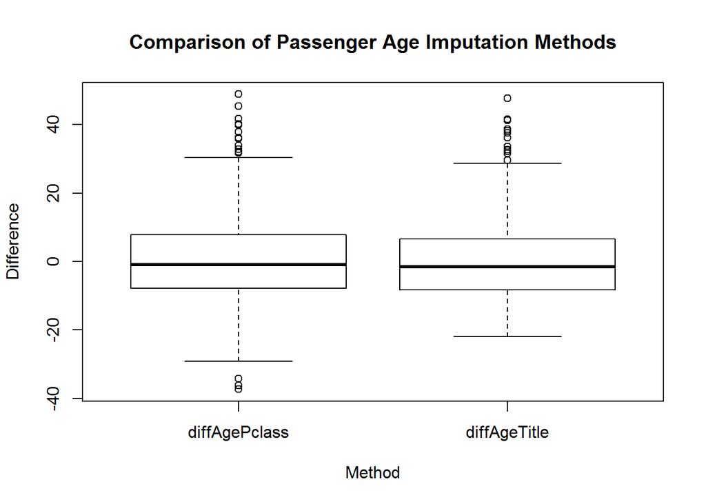

```r
comparison <- train %>%
    ungroup() %>%
    filter(!is.na(Age)) %>%
    mutate(diffAgePclass = Age - AgePclass,
           diffAgeTitle = Age - AgeTitle) %>%
    select(PassengerId, diffAgePclass, diffAgeTitle) %>%
    melt(id.vars = c("PassengerId"),
         measure.vars = c("diffAgePclass", "diffAgeTitle")) %>%
    select(value, variable)

boxplot(comparison$value ~ comparison$variable,
        main = "Comparison of Passenger Age Imputation Methods",
        xlab = "Method",
        ylab = "Difference")
```

This analysis shows that both imputation methods introduce some variation, but overall the second, more complex, method involving the passengers titles seems to perform slightly better. Hence I decided to follow Curt and use this method to impute the missing ages.

#### Actual imputation

For performing the imputation of missing ages I reuse Curt’s ideas but rewrote them partially using the `dplyr` syntax:

```r
titlesToImpute <- train %>%
    group_by(Title) %>%
    summarise(missing = sum(is.na(Age))) %>%
    filter(missing > 0) %>%
    select(Title) %>%
    collect %>%
    .[["Title"]]

# function for imputing missing age information for certain passengers taken
# from https://github.com/wehrley/wehrley.github.io/blob/master/SOUPTONUTS.md
imputeMedian <- function(impute.var, filter.var, var.levels) {
    for(v in var.levels) {
    impute.var[which(filter.var == v)] <-
        Hmisc::impute(impute.var[which(filter.var == v)])
    }
    return(impute.var)
}

train$Age <- imputeMedian(train$Age,
                          train$Title,
                          titlesToImpute)
```

### Embarkation port

Since only 2 samples are missing information on their port of embarkation I assumed it reasonable to assign them to the majority of people who embarked in Southampton:

```r
round(prop.table(table(train$Embarked)) * 100, 1)
```

```
##
##    C    Q    S
## 18.9  8.7 72.4
```

```r
train$Embarked[which(is.na(train$Embarked))] <- 'S'
```

### Fare

There are no missing values for the ticket fares, but a number of null values:

```r
train %>%
    filter(Fare == 0) %>%
    select(PassengerId, Name, Age, Fare)
```

```
## Source: local data frame [15 x 5]
## Groups: Title
##
##       Title PassengerId                             Name Age Fare
## 1        Mr         180              Leonard, Mr. Lionel  36    0
## 2        Mr         264            Harrison, Mr. William  40    0
## 3        Mr         272     Tornquist, Mr. William Henry  25    0
## 4        Mr         278      Parkes, Mr. Francis "Frank"  30    0
## 5        Mr         303  Johnson, Mr. William Cahoone Jr  19    0
## 6        Mr         414   Cunningham, Mr. Alfred Fleming  30    0
## 7        Mr         467            Campbell, Mr. William  30    0
## 8        Mr         482 Frost, Mr. Anthony Wood "Archie"  30    0
## 9        Mr         598              Johnson, Mr. Alfred  49    0
## 10       Mr         634    Parr, Mr. William Henry Marsh  30    0
## 11       Mr         675       Watson, Mr. Ennis Hastings  30    0
## 12       Mr         733             Knight, Mr. Robert J  30    0
## 13       Mr         807           Andrews, Mr. Thomas Jr  39    0
## 14       Mr         816                 Fry, Mr. Richard  30    0
## 15 Jonkheer         823  Reuchlin, Jonkheer. John George  38    0
```

If we assume these to be missing values we can easily impute ticket fares by reusing the `imputeMedian` function we formulated above:

```r
train$Fare[which(train$Fare == 0 )] <- NA
train$Fare <- imputeMedian(train$Fare,
                           train$Pclass,
                           as.numeric(levels(train$Pclass)))
```

## Feature Engineering

### Title

Curt then goes on to suggest engineering a new variable to respresent the social status of each passenger, derived from the aforementioned title attribute. It is easily visible that the ages of the passengers vary greatly by their title, and that the titles can be put in a certain descending order of social class and be grouped accordingly:

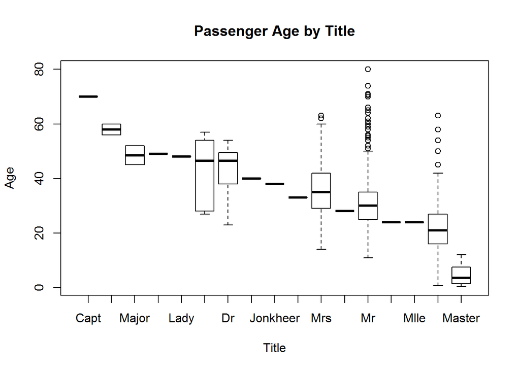

```r
train$Title <- factor(train$Title,
                      c("Capt", "Col", "Major", "Sir", "Lady", "Rev", "Dr",
                        "Don", "Jonkheer", "the Countess" ,"Mrs", "Ms", "Mr",
                        "Mme", "Mlle", "Miss", "Master"))

boxplot(train$Age ~ train$Title,
        main = "Passenger Age by Title",
        xlab = "Title",
        ylab = "Age")
```

```r
train$Title <- as.character(train$Title)
train$Title[which(train$Title %in% c("Capt", "Col", "Don", "Dr", "Jonkheer",
                                     "Lady", "Major", "Rev", "Sir"))] <- "Noble"
train$Title[which(train$Title %in% c("the Countess", "Ms"))] <- "Mrs"
train$Title[which(train$Title %in% c("Mlle", "Mme"))] <- "Miss"
train$Title <- as.factor(train$Title)
```

### Other variables

Curt also renamed and generated a host of other variables for use in the model:

```r
## test a character as an EVEN single digit
isEven <- function(x) x %in% c("0","2","4","6","8")
## test a character as an ODD single digit
isOdd <- function(x) x %in% c("1","3","5","7","9")

## function to add features to training or test data frames
featureEngrg <- function(data) {
  ## Using Fate ILO Survived because term is shorter and just sounds good
  data$Fate <- data$Survived
  ## Revaluing Fate factor to ease assessment of confusion matrices later
  data$Fate <- revalue(data$Fate, c("1" = "Survived", "0" = "Perished"))
  ## Boat.dibs attempts to capture the "women and children first"
  ## policy in one feature.  Assuming all females plus males under 15
  ## got "dibs' on access to a lifeboat
  data$Boat.dibs <- "No"
  data$Boat.dibs[which(data$Sex == "female" | data$Age < 15)] <- "Yes"
  data$Boat.dibs <- as.factor(data$Boat.dibs)
  ## Family consolidates siblings and spouses (SibSp) plus
  ## parents and children (Parch) into one feature
  data$Family <- data$SibSp + data$Parch
  ## Fare.pp attempts to adjust group purchases by size of family
  data$Fare.pp <- data$Fare/(data$Family + 1)
  ## Giving the traveling class feature a new look
  data$Class <- data$Pclass
  data$Class <- revalue(data$Class,
                        c("1"="First", "2"="Second", "3"="Third"))
  ## First character in Cabin number represents the Deck
  data$Deck <- substring(data$Cabin, 1, 1)
  data$Deck[ which( is.na(data$Deck ))] <- "UNK"
  data$Deck <- as.factor(data$Deck)
  ## Odd-numbered cabins were reportedly on the port side of the ship
  ## Even-numbered cabins assigned Side="starboard"
  data$cabin.last.digit <- str_sub(data$Cabin, -1)
  data$Side <- "UNK"
  data$Side[which(isEven(data$cabin.last.digit))] <- "port"
  data$Side[which(isOdd(data$cabin.last.digit))] <- "starboard"
  data$Side <- as.factor(data$Side)
  data$cabin.last.digit <- NULL
  return (data)
}

## add remaining features to training data frame
train <- featureEngrg(train) %>%
    select(Fate, Sex, Boat.dibs, Age, Title, Class, Deck, Side, Fare, Fare.pp,
           Embarked, Family)
```

## Fitting a model

### Splitting the data

In order to be able to fit and validate our models we need a (true) training dataset and a validation dataset, here an 80/20-split:

```r
set.seed(23)
training.rows <- createDataPartition(train$Fate,
                                     p = 0.8,
                                     list = FALSE)
train.batch <- train[training.rows, ]
test.batch <- train[-training.rows, ]
```

### Simple linear regression

Since it’s simple and sturdy, our first attempt at modeling has to be a linear regression with six basic parameters:

```r
model1 <- glm(Fate ~ Sex + Class + Age + Family + Embarked + Fare,
              data = train.batch,
              family = binomial("logit"))
```

Compared to a null-deviance of 951 our model reduced the deviance to 631, quite an improvement for a first shot. The number of 8 degrees of freedom stems from the categorical variables `Sex` (2 classes), `Class` (3 classes), and `Embarked` (3 classes).

Now let’s see if we can improve the logit model by removing some of these parameters. ANOVA is a good way to do this, since it reveals how strong each parameter is involved in the prediction of our outcome class (i.e. reduction in deviance from the random null-model):

```r
anova(model1, test="Chisq")
```

```
## Analysis of Deviance Table
##
## Model: binomial, link: logit
##
## Response: Fate
##
## Terms added sequentially (first to last)
##
##
##          Df Deviance Resid. Df Resid. Dev  Pr(>Chi)
## NULL                       713     950.86
## Sex       1  202.688       712     748.18 < 2.2e-16 ***
## Class     2   76.110       710     672.07 < 2.2e-16 ***
## Age       1   23.707       709     648.36 1.122e-06 ***
## Family    1   11.367       708     636.99 0.0007474 ***
## Embarked  2    5.482       706     631.51 0.0645202 .
## Fare      1    0.495       705     631.02 0.4818720
## ---
## Signif. codes:  0 '***' 0.001 '**' 0.01 '*' 0.05 '.' 0.1 ' ' 1
```

As expected (or shown by our descriptive analyses above), sex and traveling class of the passengers had great influence on whether or not they survived. In contrast, the fare and embarkation port do not seem to have to much influence. Let’s try to fix the former by employing the per-person fare we calculated earlier:

```r
model2 <- glm(Fate ~ Sex + Class + Age + Family + Embarked + Fare.pp,
              data = train.batch,
              family = binomial("logit"))
anova(model2, test="Chisq")
```

```
## Analysis of Deviance Table
##
## Model: binomial, link: logit
##
## Response: Fate
##
## Terms added sequentially (first to last)
##
##
##          Df Deviance Resid. Df Resid. Dev  Pr(>Chi)
## NULL                       713     950.86
## Sex       1  202.688       712     748.18 < 2.2e-16 ***
## Class     2   76.110       710     672.07 < 2.2e-16 ***
## Age       1   23.707       709     648.36 1.122e-06 ***
## Family    1   11.367       708     636.99 0.0007474 ***
## Embarked  2    5.482       706     631.51 0.0645202 .
## Fare.pp   1    0.274       705     631.24 0.6008925
## ---
## Signif. codes:  0 '***' 0.001 '**' 0.01 '*' 0.05 '.' 0.1 ' ' 1
```

Now that didn’t help at all, the deviance for `Fare.pp` is even lower than `Fare`’s! So let’s throw it out altogether:

```r
model3 <- glm(Fate ~ Sex + Class + Age + Family + Embarked,
              data = train.batch,
              family = binomial("logit"))
anova(model3, test="Chisq")
```

```
## Analysis of Deviance Table
##
## Model: binomial, link: logit
##
## Response: Fate
##
## Terms added sequentially (first to last)
##
##
##          Df Deviance Resid. Df Resid. Dev  Pr(>Chi)
## NULL                       713     950.86
## Sex       1  202.688       712     748.18 < 2.2e-16 ***
## Class     2   76.110       710     672.07 < 2.2e-16 ***
## Age       1   23.707       709     648.36 1.122e-06 ***
## Family    1   11.367       708     636.99 0.0007474 ***
## Embarked  2    5.482       706     631.51 0.0645202 .
## ---
## Signif. codes:  0 '***' 0.001 '**' 0.01 '*' 0.05 '.' 0.1 ' ' 1
```

### 10-fold cross-validated logistic regression

In order to be able to compare the performance of our model to other, more involved modeling techniques we will employ the `caret` package, and initialize an appropriate control function. This will allow us to plot the ROC curves later and pick the best-performing model.

```r
cv.ctrl <- trainControl(method = "repeatedcv",
                        repeats = 3,
                        summaryFunction = twoClassSummary,
                        classProbs = TRUE)
```

And run the last linear regression model we fitted above:

```r
set.seed(35)
model4 <- train(Fate ~ Sex + Class + Age + Family + Embarked,
                data = train.batch,
                method = "glm",
                metric = "ROC",
                trControl = cv.ctrl)
summary(model4)
```

```
##
## Call:
## NULL
##
## Deviance Residuals:
##     Min       1Q   Median       3Q      Max
## -2.2185  -0.6152  -0.4226   0.6375   2.4717
##
## Coefficients:
##             Estimate Std. Error z value Pr(>|z|)
## (Intercept)  2.00108    0.43066   4.647 3.37e-06 ***
## Sexfemale    2.64146    0.22237  11.879  < 2e-16 ***
## ClassSecond -1.24511    0.30481  -4.085 4.41e-05 ***
## ClassThird  -2.43879    0.28496  -8.558  < 2e-16 ***
## Age         -0.04542    0.00882  -5.149 2.61e-07 ***
## Family      -0.21021    0.07263  -2.894   0.0038 **
## EmbarkedQ   -0.12801    0.41992  -0.305   0.7605
## EmbarkedS   -0.57039    0.26374  -2.163   0.0306 *
## ---
## Signif. codes:  0 '***' 0.001 '**' 0.01 '*' 0.05 '.' 0.1 ' ' 1
##
## (Dispersion parameter for binomial family taken to be 1)
##
##     Null deviance: 950.86  on 713  degrees of freedom
## Residual deviance: 631.51  on 706  degrees of freedom
## AIC: 647.51
##
## Number of Fisher Scoring iterations: 5
```

Still a deviance of 632. Curt suggested to introduce a compressed factor from the `Embarked` variable like this:

```r
set.seed(35)
model5 <- train(Fate ~ Sex + Class + Age + Family + I(Embarked == "S"),
                data = train.batch,
                method = "glm",
                metric = "ROC",
                trControl = cv.ctrl)
summary(model5)
```

```
##
## Call:
## NULL
##
## Deviance Residuals:
##     Min       1Q   Median       3Q      Max
## -2.2050  -0.6164  -0.4208   0.6426   2.4755
##
## Coefficients:
##                           Estimate Std. Error z value Pr(>|z|)
## (Intercept)               1.974766   0.421336   4.687 2.77e-06 ***
## Sexfemale                 2.637404   0.221797  11.891  < 2e-16 ***
## ClassSecond              -1.255287   0.302867  -4.145 3.40e-05 ***
## ClassThird               -2.460789   0.275768  -8.923  < 2e-16 ***
## Age                      -0.045467   0.008811  -5.160 2.47e-07 ***
## Family                   -0.208482   0.072311  -2.883  0.00394 **
## `I(Embarked == "S")TRUE` -0.529630   0.227416  -2.329  0.01986 *
## ---
## Signif. codes:  0 '***' 0.001 '**' 0.01 '*' 0.05 '.' 0.1 ' ' 1
##
## (Dispersion parameter for binomial family taken to be 1)
##
##     Null deviance: 950.86  on 713  degrees of freedom
## Residual deviance: 631.60  on 707  degrees of freedom
## AIC: 645.6
##
## Number of Fisher Scoring iterations: 5
```

Since we put so much effortinto it, let’s include out `Title` factor in the model:

```r
set.seed(35)
model6 <- train(Fate ~ Sex + Class + Title + Age + Family + I(Embarked=="S"),
                data = train.batch,
                method = "glm",
                metric = "ROC",
                trControl = cv.ctrl)
summary(model6)
```

```
##
## Call:
## NULL
##
## Deviance Residuals:
##     Min       1Q   Median       3Q      Max
## -2.3476  -0.5765  -0.3877   0.5734   2.4953
##
## Coefficients:
##                           Estimate Std. Error z value Pr(>|z|)
## (Intercept)                4.70447    0.65161   7.220 5.21e-13 ***
## Sexfemale                 15.28525  623.55543   0.025 0.980443
## ClassSecond               -1.43867    0.33135  -4.342 1.41e-05 ***
## ClassThird                -2.54556    0.29641  -8.588  < 2e-16 ***
## TitleMiss                -15.57857  623.55565  -0.025 0.980068
## TitleMr                   -3.04656    0.57156  -5.330 9.81e-08 ***
## TitleMrs                 -14.53106  623.55571  -0.023 0.981408
## TitleNoble                -3.13799    0.82733  -3.793 0.000149 ***
## Age                       -0.03695    0.01065  -3.471 0.000518 ***
## Family                    -0.43025    0.08915  -4.826 1.39e-06 ***
## `I(Embarked == "S")TRUE`  -0.55423    0.23509  -2.358 0.018395 *
## ---
## Signif. codes:  0 '***' 0.001 '**' 0.01 '*' 0.05 '.' 0.1 ' ' 1
##
## (Dispersion parameter for binomial family taken to be 1)
##
##     Null deviance: 950.86  on 713  degrees of freedom
## Residual deviance: 588.32  on 703  degrees of freedom
## AIC: 610.32
##
## Number of Fisher Scoring iterations: 13
```

Well well, another success regarding our model deviance measure, which is now at 588.

## Evaluating a model

Now let’s see how well our model, which we trained on the true training dataset, performs on our training or validation dataset (remember: the kaggle competition tiself contains a training and a test dataset!).

```r
glm.pred <- predict(model6, test.batch)
confMat <- confusionMatrix(glm.pred, test.batch$Fate)
```

And here’s the ROC curve for our logistic regression model:

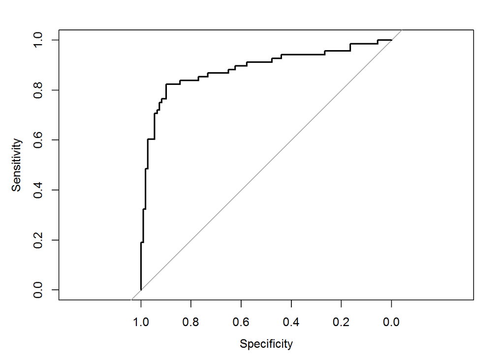

```
##
## Call:
## roc.default(response = test.batch$Fate, predictor = glm.probs$Survived,     levels = levels(test.batch$Fate))
##
## Data: glm.probs$Survived in 109 controls (test.batch$Fate Perished) < 68 cases (test.batch$Fate Survived).
## Area under the curve: 0.8862
```

```r
glm.probs <- predict(model6,
                     test.batch,
                     type = "prob")
glm.ROC <- roc(response = test.batch$Fate,
               predictor = glm.probs$Survived,
               levels = levels(test.batch$Fate))
plot(glm.ROC, type = "S")
```

## Submitting a model to kaggle

Now’s the time to finish up: Let’s apply all our data-munging to the test data that was provided as part of the kaggle competition first:

```r
test$Title <- substr(test$Name,
                      regexpr("\\,[A-Z ]{1,20}\\.",
                              test$Name,
                              TRUE) + 2,
                      regexpr("\\,[A-Z ]{1,20}\\.",
                              test$Name,
                              TRUE) +
                          attr(regexpr("\\,[A-Z ]{1,20}\\.",
                                       test$Name,
                                       TRUE),
                               "match.length") - 2)
test$Title[which(test$Title %in% c("Dona", "Ms"))] <- "Mrs"
titlesToImpute <- test %>%
    group_by(Title) %>%
    summarise(missing = sum(is.na(Age))) %>%
    filter(missing > 0) %>%
    select(Title) %>%
    collect %>%
    .[["Title"]]
test$Age <- imputeMedian(test$Age,
                         test$Title,
                         titlesToImpute)

test$Title[which(test$Title %in% c("Col", "Dr", "Rev"))] <- "Noble"
test$Title[which(test$Title %in% c("Mlle", "Mme"))] <- "Miss"
test$Title <- as.factor(test$Title)

test$Fare[which(test$Fare == 0 )] <- NA
test$Fare <- imputeMedian(test$Fare,
                          test$Pclass,
                          as.numeric(levels(test$Pclass)))

test <- featureEngrg(test) %>%
    select(PassengerId, Sex, Boat.dibs, Age, Title, Class, Deck, Side, Fare, Fare.pp,
           Embarked, Family)
```

And then let’s use our model to predict the survivors from the test dataset:

```r
Survived <- predict(model6, newdata = test)
Survived <- revalue(Survived, c("Survived" = 1, "Perished" = 0))
predictions <- as.data.frame(Survived)
predictions$PassengerId <- test$PassengerId
```

Finally let’s write our predictions to a CSV file which we can then submit to kaggle competition:

```r
write.csv(predictions[, c("PassengerId", "Survived")],
          file="predictions.csv",
          row.names=FALSE,
          quote=FALSE)
```

This attempt scored me 0.77990 points on the public leaderboard, on 1470th position… ;o) There’s definitely room for improvment here!

//kg